# head02 (B46, Modem 231708) — Analyse des Datenausfalls Februar 2026

Neuauswertung nach den Encoder-Regeln der Firmware TempLoggerHead_5-06

Author

Thom Laepple

Published

September 1, 2026

head02 stand an **B46** und wurde abgestellt, nachdem die Daten unbrauchbar wurden. Grundlage sind die 204 MO-Nachrichten in `data/messages-1781290180297_old.csv` (13.01.–17.02.2026). Der Kopf ist nicht in `decode_combined.R` eingebunden; hier wird direkt aus dem Payload dekodiert — mit den Regeln der Firmware (`~/sharedAI/FirmwareTempLoggerHead/TempLoggerHead_5-06.cpp`), weil ein Decoder mit festen Feldbreiten die Telegramme falsch liest.

Drei Firmware-Eigenschaften bestimmen die Auswertung:

- **Bytebreiten sind wertabhängig** (1–4 B je nach Betrag), nicht feldfest. Wächst ein Wert über 32767, belegt er 3 statt 2 Byte und verschiebt alles Folgende.
- **Druck-Timeout**: Antwortet ein Knoten binnen 2 s nicht auf `P`, schreibt die Firmware zweimal die 111 → `6F 6F`, also 2 statt 3 Byte.
- **`ArrayLen()`** beendet die Nachricht nach fünf Nullbytes. Der Overflow-Sentinel `01 00 00 00` enthält drei Nullbytes und kann die Nachricht damit selbst abschneiden.

```r
library(readr); library(dplyr); library(tidyr); library(lubridate)
library(ggplot2); library(patchwork)

raw <- read_csv("./data/messages-1781290180297_old.csv", show_col_types = FALSE) |>
  filter(grepl("231708", Device)) |>
  transmute(recv = dmy_hms(`Date Time (UTC)`, tz = "UTC"),
            nbytes = `Length (Bytes)`, hex = tolower(Payload)) |>
  arrange(recv)

s_int <- function(h) { v <- strtoi(h, 16L); n <- nchar(h)/2; ifelse(v >= 2^(8*n-1), v - 2^(8*n), v) }

# Knotenweiser Parser: NTC(3) + GND(2 oder 3) + Druck(3 oder 6F6F).
# Die GND-Breite folgt aus der Position des nächsten 6F6F bzw. aus der Restlänge.
parse_msg <- function(h) {
  n <- nchar(h); if (n < 60) return(NULL)
  p <- 15L                                   # nach 4 B Zeit + 3 B ADC (14 Hex-Zeichen)
  out <- list()
  while (p + 15L <= n - 4L) {
    ntc <- s_int(substr(h, p, p + 5L)); p <- p + 6L
    nxt2 <- substr(h, p + 4L, p + 7L); nxt3 <- substr(h, p + 6L, p + 9L)
    if (identical(nxt2, "6f6f"))      { gnd <- s_int(substr(h, p, p+3L)); p <- p + 4L; pres <- NA; p <- p + 4L }
    else if (identical(nxt3, "6f6f")) { gnd <- s_int(substr(h, p, p+5L)); p <- p + 6L; pres <- NA; p <- p + 4L }
    else { gnd <- s_int(substr(h, p, p+3L)); p <- p + 4L
           pres <- strtoi(substr(h, p, p+5L), 16L); p <- p + 6L }
    out[[length(out)+1]] <- tibble(node = length(out)+1L, ntc = ntc, gnd = gnd, pres = pres)
  }
  bind_rows(out)
}

msg <- raw |> mutate(
  sep     = lengths(regmatches(hex, gregexpr("7c", hex))),
  tmo     = lengths(regmatches(hex, gregexpr("6f6f", hex))),
  t_int   = as_datetime(strtoi(substr(hex, 1, 8), 16L)),
  # Platinentemperatur steht in Byte 5–7 — nur im trennerlosen Format; in den
  # 0x7C-Telegrammen und im 334-B-Format liegt dort ein Knotenwert.
  adc_ok  = sep <= 10 & nbytes >= 150 & nbytes <= 300,
  adc_C   = ifelse(adc_ok, 6.101e-5 * strtoi(substr(hex, 9, 14), 16L) - 256.6, NA_real_),
  adc_out = !is.na(adc_C) & (adc_C > -35 | adc_C < -50),
  format  = case_when(sep > 10 ~ "sep (0x7C)", nbytes < 150 ~ "gekürzt", TRUE ~ "nosep"))

nodes <- msg |> filter(format != "sep (0x7C)") |>
  rowwise() |> mutate(d = list(parse_msg(hex))) |> ungroup() |>
  select(recv, nbytes, format, d) |> unnest(d)

EVENT <- as_datetime("2026-02-02 15:00:00")
```

## Befund

```r
pre  <- nodes |> filter(recv < EVENT, nbytes == 209)
post <- nodes |> filter(recv > EVENT, nbytes > 150)
tmo_pre  <- msg |> filter(recv < EVENT, nbytes == 209) |> summarise(m = mean(tmo)) |> pull(m)
tmo_post <- msg |> filter(recv > EVENT, nbytes > 150) |> summarise(m = mean(tmo)) |> pull(m)
# Dauerhafter Ausfall = ab hier folgt keine saubere Nachricht mehr
clean <- msg$tmo == 0 & msg$nbytes > 150
first_bad <- msg[max(which(clean)) + 1L, ]
# Vorläufer: Timeouts vor dem dauerhaften Ausfall
prec <- msg |> filter(tmo > 0, recv < EVENT)
last_good <- msg |> filter(recv < EVENT, nbytes == 209) |> slice_max(recv, n = 1)

cat(sprintf("- **Bis %s UTC arbeitete die Kette vollständig**: 25 Knoten, NTC1 als geordnetes Tiefenprofil, GND bei −700 bis −900 Counts, Druck %.0f–%.0f (≙ %.0f–%.0f hPa), **kein einziger Druck-Timeout**.\n",
  format(last_good$recv, "%d.%m.%Y %H:%M"),
  min(pre$pres, na.rm=TRUE), max(pre$pres, na.rm=TRUE),
  min(pre$pres, na.rm=TRUE)/1000, max(pre$pres, na.rm=TRUE)/1000))
```

[output not shown]

```r
cat(sprintf("- **Ab %s UTC melden alle Knoten Druck-Timeout** (`6F 6F`, im Mittel %.0f Marker pro Nachricht gegenüber %.1f davor); danach folgt keine saubere Nachricht mehr. Der digitale Teil der Kette antwortet nicht.\n",
  format(first_bad$recv, "%d.%m.%Y %H:%M"), tmo_post, tmo_pre))
```

- **Ab 02.02.2026 17:13 UTC melden alle Knoten Druck-Timeout** (`6F 6F`, im Mittel 25 Marker pro Nachricht gegenüber 0.3 davor); danach folgt keine saubere Nachricht mehr. Der digitale Teil der Kette antwortet nicht.

```r
cat(sprintf("- **Vorläufer am 19.01.2026:** drei aufeinanderfolgende Nachrichten (%s–%s UTC, rund %.0f Stunden) zeigen bereits 25 Timeouts — danach lief die Kette wieder vollständig, mit einem einzelnen Timeout am 24.01. Der Ausfall kündigte sich also als **aussetzender Kontakt** an, bevor er dauerhaft wurde.\n",
  format(min(prec$recv), "%d.%m. %H:%M"), format(max(prec$recv[prec$recv < as_datetime("2026-01-21")]), "%H:%M"),
  as.numeric(difftime(max(prec$recv[prec$recv < as_datetime("2026-01-21")]), min(prec$recv), units = "hours"))))
```

- **Vorläufer am 19.01.2026:** drei aufeinanderfolgende Nachrichten (19.01. 12:57–20:57 UTC, rund 8 Stunden) zeigen bereits 25 Timeouts — danach lief die Kette wieder vollständig, mit einem einzelnen Timeout am 24.01. Der Ausfall kündigte sich also als **aussetzender Kontakt** an, bevor er dauerhaft wurde.

```r
cat(sprintf("- **Gleichzeitig lesen NTC1 und GND denselben Wert**: Median NTC1 %s, Median GND %s Counts, Differenz %s — vor dem Ereignis lagen sie um Größenordnungen auseinander (NTC1 %s, GND %s). Beide Kanäle sehen dasselbe Potenzial; die Werte laufen innerhalb einer Nachricht glatt durch (Drift eines nicht angesteuerten Eingangs), statt ein Profil abzubilden.\n",
  format(round(median(post$ntc, na.rm=TRUE)), big.mark="."), format(round(median(post$gnd, na.rm=TRUE)), big.mark="."),
  format(round(median(post$ntc - post$gnd, na.rm=TRUE)), big.mark="."),
  format(round(median(pre$ntc, na.rm=TRUE)), big.mark="."), format(round(median(pre$gnd, na.rm=TRUE)), big.mark=".")))
```

- **Gleichzeitig lesen NTC1 und GND denselben Wert**: Median NTC1 -320.075, Median GND -291.403 Counts, Differenz -1.162 — vor dem Ereignis lagen sie um Größenordnungen auseinander (NTC1 4.171.408, GND -782). Beide Kanäle sehen dasselbe Potenzial; die Werte laufen innerhalb einer Nachricht glatt durch (Drift eines nicht angesteuerten Eingangs), statt ein Profil abzubilden.

```r
cat(sprintf("- **Die verkürzten Telegramme am 02./03.02. (10–133 B) sind ein `ArrayLen()`-Artefakt, kein Sendeabbruch.** Sie enden jeweils exakt auf `6f6f 01 00 00` — erster Druck-Timeout, dann Overflow-Sentinel, dessen Nullbytes die Nachricht abschneiden. Die 0 mV, die ein Decoder mit fester Feldbreite dort als Batterie liest, sind Teil des Sentinels.\n"))
```

- **Die verkürzten Telegramme am 02./03.02. (10–133 B) sind ein `ArrayLen()`-Artefakt, kein Sendeabbruch.** Sie enden jeweils exakt auf `6f6f 01 00 00` — erster Druck-Timeout, dann Overflow-Sentinel, dessen Nullbytes die Nachricht abschneiden. Die 0 mV, die ein Decoder mit fester Feldbreite dort als Batterie liest, sind Teil des Sentinels.

```r
cat(sprintf("- **Logger und Modem blieben intakt**: Zeitstempel plausibel, Platinentemperatur %.2f °C am 02.02. → %.2f °C am 17.02. (glatte Drift %.2f K).\n",
  msg$adc_C[max(which(msg$recv < EVENT))], tail(msg$adc_C,1),
  tail(msg$adc_C,1) - msg$adc_C[max(which(msg$recv < EVENT))]))
```

- **Logger und Modem blieben intakt**: Zeitstempel plausibel, Platinentemperatur -41.23 °C am 02.02. → -40.88 °C am 17.02. (glatte Drift 0.35 K).

```r
cat("- head03 und head04 sendeten am 02./03.02.2026 unauffällig weiter — kein standortweites Ereignis.\n")
```

- head03 und head04 sendeten am 02./03.02.2026 unauffällig weiter — kein standortweites Ereignis.

## Verlauf

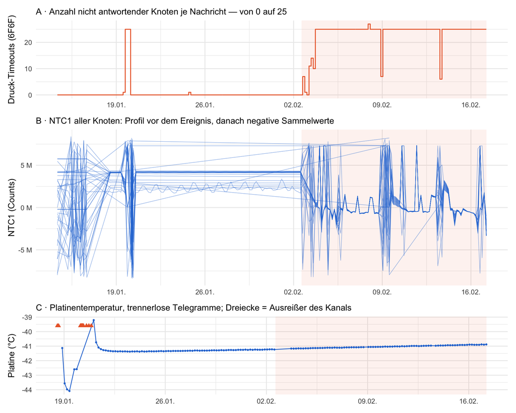

```r
BLUE <- "#2a78d6"; ORANGE <- "#eb6834"
p1 <- ggplot(msg |> filter(format != "sep (0x7C)"), aes(recv, tmo)) +
  annotate("rect", xmin = EVENT, xmax = max(msg$recv), ymin = -Inf, ymax = Inf, fill = ORANGE, alpha = 0.08) +
  geom_step(colour = ORANGE, linewidth = 0.6) +
  scale_y_continuous("Druck-Timeouts (6F6F)") + scale_x_datetime(NULL, date_labels = "%d.%m.") +
  labs(subtitle = "A · Anzahl nicht antwortender Knoten je Nachricht — von 0 auf 25") +
  theme_minimal(base_size = 12)

p2 <- ggplot(nodes |> filter(!is.na(ntc)), aes(recv, ntc, group = node)) +
  annotate("rect", xmin = EVENT, xmax = max(msg$recv), ymin = -Inf, ymax = Inf, fill = ORANGE, alpha = 0.08) +
  geom_line(colour = BLUE, alpha = 0.5, linewidth = 0.3) +
  scale_y_continuous("NTC1 (Counts)", labels = scales::label_number(scale = 1e-6, suffix = " M")) +
  scale_x_datetime(NULL, date_labels = "%d.%m.") +
  labs(subtitle = "B · NTC1 aller Knoten: Profil vor dem Ereignis, danach negative Sammelwerte") +
  theme_minimal(base_size = 12)

p3 <- ggplot(msg |> filter(!is.na(adc_C), !adc_out), aes(recv, adc_C)) +
  annotate("rect", xmin = EVENT, xmax = max(msg$recv), ymin = -Inf, ymax = Inf, fill = ORANGE, alpha = 0.08) +
  geom_line(colour = BLUE, linewidth = 0.5) + geom_point(colour = BLUE, size = 0.7) +
  geom_point(data = msg |> filter(adc_out), aes(recv, -39.6), colour = ORANGE, shape = 17, size = 2) +
  scale_y_continuous("Platine (°C)") + scale_x_datetime(NULL, date_labels = "%d.%m.") +
  labs(subtitle = "C · Platinentemperatur, trennerlose Telegramme; Dreiecke = Ausreißer des Kanals") +
  theme_minimal(base_size = 12)

p1 / p2 / p3 + plot_layout(heights = c(1, 2, 1))
```

## Profil vor dem Ausfall

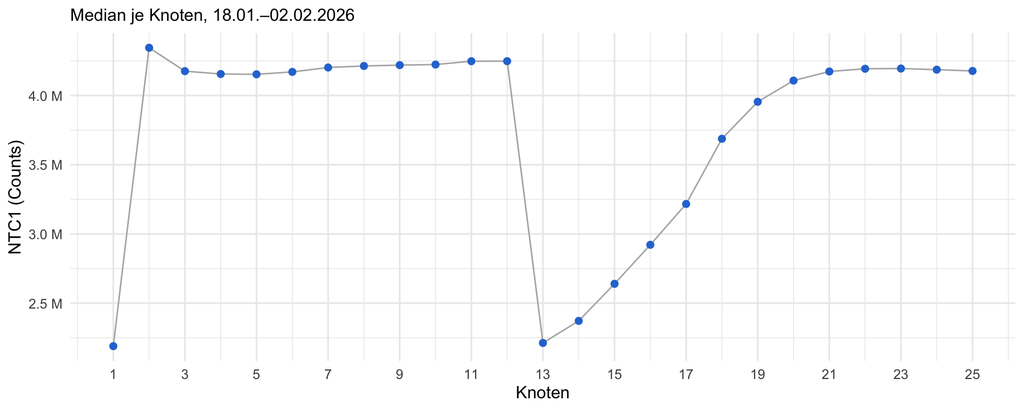

```r
pre |> group_by(node) |> summarise(ntc = median(ntc, na.rm = TRUE), .groups = "drop") |>
  ggplot(aes(node, ntc)) +
  geom_line(colour = "grey70") + geom_point(colour = BLUE, size = 2) +
  scale_y_continuous("NTC1 (Counts)", labels = scales::label_number(scale = 1e-6, suffix = " M")) +
  scale_x_continuous("Knoten", breaks = seq(1, 25, 2)) +
  labs(subtitle = "Median je Knoten, 18.01.–02.02.2026") +
  theme_minimal(base_size = 12)
```

## Spannweite der Platinentemperatur

```r
a <- msg |> filter(!is.na(adc_C))
knitr::kable(bind_rows(
  a |> filter(!adc_out) |> summarise(Reihe = "regulär", n = n(),
        von = format(min(recv), "%d.%m."), bis = format(max(recv), "%d.%m."),
        `min (°C)` = round(min(adc_C), 2), `max (°C)` = round(max(adc_C), 2),
        `Spannweite (K)` = round(diff(range(adc_C)), 2)),
  a |> filter(!adc_out, recv < EVENT) |> summarise(Reihe = "vor 02.02.", n = n(),
        von = format(min(recv), "%d.%m."), bis = format(max(recv), "%d.%m."),
        `min (°C)` = round(min(adc_C), 2), `max (°C)` = round(max(adc_C), 2),
        `Spannweite (K)` = round(diff(range(adc_C)), 2)),
  a |> filter(!adc_out, recv >= EVENT) |> summarise(Reihe = "nach 02.02.", n = n(),
        von = format(min(recv), "%d.%m."), bis = format(max(recv), "%d.%m."),
        `min (°C)` = round(min(adc_C), 2), `max (°C)` = round(max(adc_C), 2),
        `Spannweite (K)` = round(diff(range(adc_C)), 2))))
```

| Reihe | n | von | bis | min (°C) | max (°C) | Spannweite (K) |
| --- | --- | --- | --- | --- | --- | --- |
| regulär | 162 | 18.01. | 17.02. | -44.09 | -39.21 | 4.88 |
| vor 02.02. | 82 | 18.01. | 02.02. | -44.09 | -39.21 | 4.88 |
| nach 02.02. | 80 | 03.02. | 17.02. | -41.17 | -40.88 | 0.29 |

```r
msg |> filter(adc_out) |> transmute(Zeit = format(recv, "%d.%m. %H:%M"), Bytes = nbytes,
        Counts = strtoi(substr(hex, 9, 14), 16L), `°C` = round(adc_C, 1)) |> knitr::kable()
```

| Zeit | Bytes | Counts | °C |
| --- | --- | --- | --- |
| 18.01. 12:53 | 209 | 4329262 | 7.5 |
| 18.01. 14:53 | 209 | 4307664 | 6.2 |
| 20.01. 03:09 | 202 | 9636438 | 331.3 |
| 20.01. 04:09 | 202 | 10947157 | 411.3 |
| 20.01. 05:09 | 202 | 10291796 | 371.3 |
| 20.01. 06:09 | 202 | 11209301 | 427.3 |
| 20.01. 07:09 | 202 | 11012692 | 415.3 |
| 20.01. 08:09 | 202 | 11340372 | 435.3 |
| 20.01. 13:12 | 209 | 4307606 | 6.2 |
| 20.01. 17:12 | 209 | 4295950 | 5.5 |
| 20.01. 21:12 | 209 | 3763830 | -27.0 |

Für 13.–16.01. gibt es keinen Wert: die `0x7C`-getrennten Telegramme und das 334-B-Format führen an dieser Stelle einen Knotenwert, keine Platinentemperatur (ein fester Offset liest dort 240 °C bzw. 754 °C).

## Die acht Stunden am 19.01.

Läuft die Kette während der Timeouts weiter — kämen also Befehle an und nur die Antwortrichtung fehlte —, müsste das analoge Tiefenprofil stehen bleiben. Der Vergleich mit einer sauberen Nachricht desselben Tages entscheidet das.

```r
# In Timeout-Nachrichten trägt jedes Segment zwischen zwei 6F6F genau NTC1 + GND.
seg_pairs <- function(h) {
  b <- substr(h, 15L, nchar(h))
  k <- lengths(regmatches(b, gregexpr("6f6f", b, fixed = TRUE)))
  if (k < 2L) return(NULL)
  parts <- strsplit(b, "6f6f", fixed = TRUE)[[1]][seq_len(k)]
  w <- nchar(parts)
  ok <- w %in% c(12L, 16L)
  tibble(node = which(ok),
         ntc = vapply(parts[ok], \(s) s_int(substr(s, 1L, nchar(s)/2)), 0),
         gnd = vapply(parts[ok], \(s) s_int(substr(s, nchar(s)/2 + 1L, nchar(s))), 0))
}
ref <- parse_msg(raw$hex[which.min(abs(difftime(raw$recv, as_datetime("2026-01-19 08:56:35"))))])

stat <- function(t) {
  h <- raw$hex[which.min(abs(difftime(raw$recv, as_datetime(t))))]
  d <- seg_pairs(h); r <- ref$ntc[d$node]
  tibble(Nachricht = format(as_datetime(t), "%d.%m. %H:%M"),
         `NTC1 (M)` = sprintf("%.2f … %.2f", min(d$ntc)/1e6, max(d$ntc)/1e6),
         `GND (M)`  = sprintf("%.2f … %.2f", min(d$gnd)/1e6, max(d$gnd)/1e6),
         `r(NTC1,GND)` = sprintf("%+.2f", cor(d$ntc, d$gnd)),
         `r(NTC1, gutes Profil)` = sprintf("%+.2f", cor(d$ntc, r)))
}
knitr::kable(bind_rows(lapply(c("2026-01-19 16:57:09", "2026-01-19 20:57:45",
                                "2026-02-05 01:12:54"), stat)))
```

| Nachricht | NTC1 (M) | GND (M) | r(NTC1,GND) | r(NTC1, gutes Profil) |
| --- | --- | --- | --- | --- |
| 19.01. 16:57 | 1.50 … 7.87 | 1.20 … 7.99 | +0.90 | +0.02 |
| 19.01. 20:57 | 5.43 … 11.45 | 5.14 … 11.40 | +0.99 | +0.07 |
| 05.02. 01:12 | -1.46 … -1.02 | -1.47 … -1.03 | +1.00 | -0.02 |

Zum Vergleich die saubere Nachricht vom 19.01. 08:56: NTC1 1,81–4,25 M Counts als geordnetes Profil, GND −728 … −876 Counts, Druck 677 hPa, kein Timeout.

Während der acht Stunden ist die Profilform vollständig weg (r ≈ 0 gegen das Profil vier Stunden davor), GND verlässt seinen Normalbereich und liegt auf demselben Pegel wie NTC1, und der Pegel driftet über die Episode (12:57 nahe der 24-Bit-Grenze bei 16,3 M, 16:57 bei 1,5–7,9 M, 20:57 bei 5,4–11,4 M; ab 02.02. bei −1,0 … −1,5 M). Vorzeichen und Betrag sind beliebig — das Verhalten eines freien, nicht angesteuerten Eingangs. Ab 20.01. 00:56 steht das Profil wieder vollständig.

## Deutung

Die Kette ist am **02.02.2026 zwischen 13:12 und 17:13 UTC** dauerhaft ausgefallen, und zwar in beiden Domänen gleichzeitig:

- **digital** — kein Knoten antwortet mehr auf den Druckbefehl (25 von 25 Timeouts);
- **analog** — NTC1- und GND-Kanal liefern denselben, driftenden Wert statt zweier getrennter Messgrößen.

Einzelne defekte Sensoren sähen anders aus (einzelne Knoten fallen aus, der Rest bleibt korrekt). Der gleichzeitige Verlust von Kommunikation und Messsignal über alle 25 Knoten zeigt auf den **gemeinsamen Pfad**: Kettenbus, Steckverbindung oder die Versorgung des Kettenzweigs. Dass Zeitstempel, Platinentemperatur und Sendebetrieb weiterlaufen, schließt Logger und Modem aus.

Der **Vorläufer am 19.01.** zeigt exakt denselben Zustand: digitale Antwort und analoges Profil fallen zusammen aus, nur eben für acht Stunden und mit vollständiger Erholung. Damit scheidet ein Fehler aus, der allein die Antwortrichtung trifft (ein einzelner Leiter, während die Knoten weiter selektiert und geschaltet werden) — dann bliebe das Profil stehen. Die Rückkehr in den Normalbetrieb spricht für einen **mechanisch aussetzenden Kontakt** (Steckverbindung, Kabelbruch mit Restkontakt) und gegen einen Halbleiterdefekt, der nicht von selbst zurückkommt.

Aus der Telemetrie allein lassen sich Bruch, Kurzschluss und Versorgungsausfall nicht trennen — das entscheidet nur eine Prüfung am Gerät. Die **SD-Karte im Kopf** speichert denselben Datensatz als ASCII in voller Auflösung und ohne die `ArrayLen()`-Kürzung; sie enthält den Ausfallzeitpunkt mit höherer Zeitauflösung als die Telemetrie.

## Nachrichtenformate von head02

```r
msg |> mutate(Format = case_when(
    sep > 10 ~ "340 + 146 B, 0x7C-getrennt (ein Datensatz, 486 B)",
    nbytes == 334 ~ "334 B ohne Trenner (25 × 13 B je Knoten)",
    nbytes == 209 ~ "209 B ohne Trenner (25 × 8 B: NTC1 3, GND 2, Druck 3)",
    nbytes < 150 ~ "gekürzt durch ArrayLen()", TRUE ~ "sonstige")) |>
  count(Format, name = "Nachrichten") |> arrange(desc(Nachrichten)) |>
  knitr::kable(caption = "Der Wechsel vom sep- ins nosep-Format am 14.01.2026 folgt aus dem EEPROM-Flag firstIridiumTransmit und liegt drei Wochen vor dem Ausfall.")
```

Der Wechsel vom sep- ins nosep-Format am 14.01.2026 folgt aus dem EEPROM-Flag firstIridiumTransmit und liegt drei Wochen vor dem Ausfall.

| Format | Nachrichten |
| --- | --- |
| 209 B ohne Trenner (25 × 8 B: NTC1 3, GND 2, Druck 3) | 151 |
| sonstige | 22 |
| 340 + 146 B, 0x7C-getrennt (ein Datensatz, 486 B) | 14 |
| gekürzt durch ArrayLen() | 9 |
| 334 B ohne Trenner (25 × 13 B je Knoten) | 8 |